# Merge province

2017-11-23

The package `poseid` contains different tools. The function `merge_prov` demonstrate in this vignette provides a method that efficiently generate time series with common spatial definitions over a given time range. To demonstrate this function, we will use the data from the `gso` package

Installing the `poseid` and `gso` packages:

```r
> devtolls::install_github("choisy/poseid")
> devtools::install_github("choisy/gso")
```

Loading and attaching the `poseid` and `gso` packages:

```r
> library(poseid)
> library(gso)
```

## Loading data

For more detail, on how to use the gso package, please look at the vignette `Introduction to GSO` contains in the `gso` package. As example, we use the data frame containing the information on the `birth and death rate`:

```r
> sel <- grep("Crude birth rate, crude death rate and natural increase rate by province",
+             gso::data_frame_summary$`data frame`)
> data_frame_summary$data_name[sel]
[1] "demography_8"
> demo <- demography_8
> head(demo)
  province year crude_birth_rate crude_death_rate natural_increase_rate
1 An Giang 2005             18.4              5.2                  13.2
2 An Giang 2007             16.9              5.1                  11.8
3 An Giang 2008             16.9              5.0                  11.9
4 An Giang 2009             17.6              8.0                   9.7
5 An Giang 2010             17.3              7.9                   9.3
6 An Giang 2011             16.4              7.3                   9.0
```

The data are expressed by year and by province:

```r
> range(demo$year)
[1] 2005 2015
> unique(demo$province)
 [1] "An Giang"          "Ba Ria - Vung Tau" "Bac Giang"
 [4] "Bac Kan"           "Bac Lieu"          "Bac Ninh"
 [7] "Ben Tre"           "Binh Dinh"         "Binh Duong"
[10] "Binh Phuoc"        "Binh Thuan"        "Ca Mau"
[13] "Can Tho"           "Cao Bang"          "Da Nang"
[16] "Dak Lak"           "Dak Nong"          "Dien Bien"
[19] "Dong Nai"          "Dong Thap"         "Gia Lai"
[22] "Ha Giang"          "Ha Nam"            "Ha Noi"
[25] "Ha Tay"            "Ha Tinh"           "Hai Duong"
[28] "Hai Phong"         "Hau Giang"         "Ho Chi Minh"
[31] "Hoa Binh"          "Hung Yen"          "Khanh Hoa"
[34] "Kien Giang"        "Kon Tum"           "Lai Chau"
[37] "Lam Dong"          "Lang Son"          "Lao Cai"
[40] "Long An"           "Nam Dinh"          "Nghe An"
[43] "Ninh Binh"         "Ninh Thuan"        "Phu Tho"
[46] "Phu Yen"           "Quang Binh"        "Quang Nam"
[49] "Quang Ngai"        "Quang Ninh"        "Quang Tri"
[52] "Soc Trang"         "Son La"            "Tay Ninh"
[55] "Thai Binh"         "Thai Nguyen"       "Thanh Hoa"
[58] "Thua Thien - Hue"  "Tien Giang"        "Tra Vinh"
[61] "Tuyen Quang"       "Vinh Long"         "Vinh Phuc"
[64] "Yen Bai"
```

## Merging data

The first utility of this function is to generate appropriate time series. One specificity of Vietnam is the splits of administrative provinces during its history, starting from 40 provinces in 1980 and ending with 63 provinces today, as illustrated below:

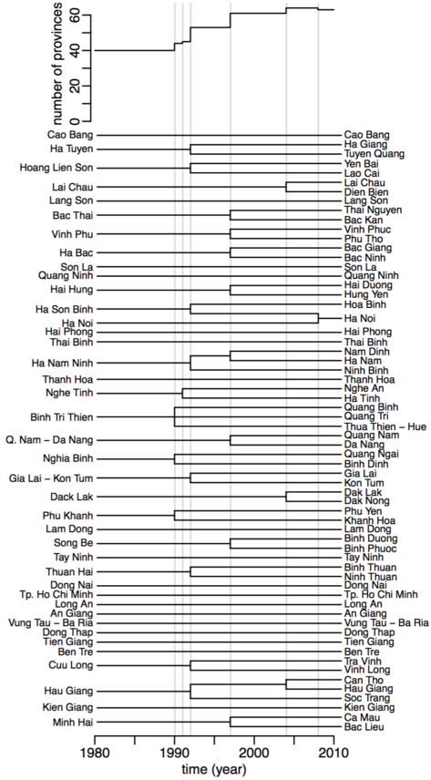

We can see that most of the events are splits event of one province into two or three provinces. There is only one merging event of provinces: Ha Noi and Ha Tay in 2008, which merged together to create a new spatial definition of Ha Noi.

The spatial definition of the provinces is changing over time. The different data frames in the `gso` package contain provinces that are thus defined over various time durations and different spatial units in time.

In order to analyze the data correctly, it is useful to work on time series that cover the same time range and with the same spatial definition through time. The function `merge_prov` takes care of this by back-merging all the provinces together and returns the data in the same spatial conformation through time.

More information on this function can be find:

```r
> ?merge_prov
Using development documentation for merge_prov
```

To have a better view of how the function works, we will select only view provinces concerned by some events of spliting or merging. For that, we will need the `dplyr` package:

```r
> library(dplyr)
```

```r
> demo <- filter(demo, is.element(province,
+                 c("Ha Noi", "Hoa Binh", "Ha Tay", "Ha Son Binh", "Dak Lak", "Dak Nong")) == TRUE)
> head(demo)
  province year crude_birth_rate crude_death_rate natural_increase_rate
1  Dak Lak 2005             22.8              5.6                  17.2
2  Dak Lak 2007             21.4              5.4                  16.0
3  Dak Lak 2008             19.6              5.4                  14.2
4  Dak Lak 2009             19.7              5.9                  13.8
5  Dak Lak 2010             19.0              5.8                  13.2
6  Dak Lak 2011             18.4              5.5                  12.9
> unique(demo$province)
[1] "Dak Lak"  "Dak Nong" "Ha Noi"   "Ha Tay"   "Hoa Binh"
```

```r
> mdemo <- merge_prov(demo, from = "2000-01-01")
> head(mdemo)
# A tibble: 6 x 4
  province  year                   key value
     <chr> <int>                 <chr> <dbl>
1 Dack Lak  2005      crude_birth_rate  49.2
2 Dack Lak  2005      crude_death_rate  11.5
3 Dack Lak  2005 natural_increase_rate  37.7
4 Dack Lak  2007      crude_birth_rate  45.5
5 Dack Lak  2007      crude_death_rate  11.3
6 Dack Lak  2007 natural_increase_rate  34.2
> unique(mdemo$province)
[1] "Dack Lak" "Ha Noi"   "Hoa Binh"
```

### Time range

Automaticaly, the time range selected is `from` to `to = 2017-12-31`. But we can change the time-range, we can use the parameters `from` and `to`, the only restriction is that the time-range selected overlaps the time range of the data frame inputted.

```r
> mdemo <- merge_prov(demo, from = 1990, to = 2010)
> head(mdemo)
# A tibble: 6 x 4
  province  year                   key value
     <chr> <int>                 <chr> <dbl>
1 Dack Lak  2005      crude_birth_rate  49.2
2 Dack Lak  2005      crude_death_rate  11.5
3 Dack Lak  2005 natural_increase_rate  37.7
4 Dack Lak  2007      crude_birth_rate  45.5
5 Dack Lak  2007      crude_death_rate  11.3
6 Dack Lak  2007 natural_increase_rate  34.2
> unique(mdemo$province)
[1] "Dack Lak" "Ha Noi"
> range(mdemo$year)
[1] 2005 2010
```

### Functions

By default, the province are merge back together by applying the function `sum`. We can change this by using the function `FUN`. For example, here, it can be more interesting here to calculate the mean than the sum when merging back together the provinces.

```r
> merge_prov(demo, from = 1990, to = 2010, FUN = mean)
# A tibble: 30 x 4
   province  year                   key value
      <chr> <int>                 <chr> <dbl>
 1 Dack Lak  2005      crude_birth_rate 24.60
 2 Dack Lak  2005      crude_death_rate  5.75
 3 Dack Lak  2005 natural_increase_rate 18.85
 4 Dack Lak  2007      crude_birth_rate 22.75
 5 Dack Lak  2007      crude_death_rate  5.65
 6 Dack Lak  2007 natural_increase_rate 17.10
 7 Dack Lak  2008      crude_birth_rate 20.90
 8 Dack Lak  2008      crude_death_rate  5.50
 9 Dack Lak  2008 natural_increase_rate 15.40
10 Dack Lak  2009      crude_birth_rate 21.25
# ... with 20 more rows
```

We can also use weighted mean by providing the weighted in another data frame, for example by the size of the population. For that, we can use the data frame `pop_size` provides in the `gso` package. The data been expressed in thousand people, we will change it.

```r
> pop_size <- gso::pop_size
> pop_size <- mutate_if(pop_size, !is.element(names(pop_size), c("province", "year")), funs(1000 * .))
> head(pop_size)
  province year  female    male   rural   total  urban
1 An Giang 1995 1003400  966700 1602100 1970100 368000
2 An Giang 1996 1012600  978100 1619800 1990700 370900
3 An Giang 1997 1022000  989100 1616000 2011100 395100
4 An Giang 1998 1031400 1001100 1634500 2032500 398000
5 An Giang 1999 1043900 1011500 1650100 2055400 405300
6 An Giang 2000 1047600 1014100 1604200 2061700 457500
```

We can now used the pop_size information in the function with the parameters `df2` and `args` to calculate the weighted mean by the total size of the population. The parameter `df2` take data frame as entry and the parameters `args` should indicate the name of the column containing the weight we want to apply on the data. The parameters `df` and `df2` should have at least one column in commun to be able to join them together.

```r
> merge_prov(demo, from = 1990, FUN = weighted.mean, df2 = pop_size, args = "total")
# A tibble: 60 x 4
   province  year                   key     value
      <chr> <int>                 <chr>     <dbl>
 1 Dack Lak  2005      crude_birth_rate 23.532414
 2 Dack Lak  2005      crude_death_rate  5.661035
 3 Dack Lak  2005 natural_increase_rate 17.871380
 4 Dack Lak  2007      crude_birth_rate 21.973244
 5 Dack Lak  2007      crude_death_rate  5.506156
 6 Dack Lak  2007 natural_increase_rate 16.467088
 7 Dack Lak  2008      crude_birth_rate 20.163343
 8 Dack Lak  2008      crude_death_rate  5.443334
 9 Dack Lak  2008 natural_increase_rate 14.720009
10 Dack Lak  2009      crude_birth_rate 20.383568
# ... with 50 more rows
```

### Selected columns

We can choose also to apply the merge_prov only on certain columns via the parameter: `sel`.

```r
> merge_prov(demo, sel = "crude_birth_rate", from = 1990, FUN = weighted.mean, df2 = pop_size, args = "total")
# A tibble: 20 x 4
   province  year              key    value
      <chr> <int>            <chr>    <dbl>
 1 Dack Lak  2005 crude_birth_rate 23.53241
 2 Dack Lak  2007 crude_birth_rate 21.97324
 3 Dack Lak  2008 crude_birth_rate 20.16334
 4 Dack Lak  2009 crude_birth_rate 20.38357
 5 Dack Lak  2010 crude_birth_rate 19.37955
 6 Dack Lak  2011 crude_birth_rate 18.67227
 7 Dack Lak  2012 crude_birth_rate 19.19159
 8 Dack Lak  2013 crude_birth_rate 20.60918
 9 Dack Lak  2014 crude_birth_rate 18.16134
10 Dack Lak  2015 crude_birth_rate 17.01668
11   Ha Noi  2005 crude_birth_rate 17.24562
12   Ha Noi  2007 crude_birth_rate 16.77564
13   Ha Noi  2008 crude_birth_rate 16.87827
14   Ha Noi  2009 crude_birth_rate 19.04832
15   Ha Noi  2010 crude_birth_rate 18.57612
16   Ha Noi  2011 crude_birth_rate 18.49432
17   Ha Noi  2012 crude_birth_rate 17.18398
18   Ha Noi  2013 crude_birth_rate 16.43757
19   Ha Noi  2014 crude_birth_rate 18.96198
20   Ha Noi  2015 crude_birth_rate 16.78185
```

### Linked to gdpm

It can be interesting to link the epidemiological data from the `gdpm` package with the informations from the `gso` package.

In the `gdpm` package, for two diseases: “hepatitis” and “amoebiasis”, the story of splits/combined provinces are different, the events of 1990 take place in 1991. For more information:

```r
> devtools::install_github("choisy/gdpm", build_vignettes = TRUE) # to install the gdpm package
> vignette(package = "gdpm")
```

```r
> library(gdpm)
> ?getid
```

```r
> hepatitis <- getid(hepatitis, from = 1990, to = 2017)
Warning in getid_(disease, vect, from = from, to = to): The argument "to" is out of the time range for this
        (these) disease(s): 1980-2015. The closest time range was selected:
        1990-2015.
```

So, if we want to link the data frame to be express with the same province as the `hepatitis` or `amoebiasis` data frame, we can use the parameter `diseases`.

```r
> demo <- demography_8
> mdemo <- merge_prov(demo, sel = "crude_birth_rate", from = 1990, FUN = weighted.mean,
+                     df2 = pop_size, args = "total")
> unique(mdemo$province)
 [1] "An Giang"            "Ba Ria - Vung Tau"   "Bac Thai"
 [4] "Ben Tre"             "Binh Dinh"           "Cao Bang"
 [7] "Cuu Long"            "Dack Lak"            "Dong Nai"
[10] "Dong Thap"           "Gia Lai - Kon Tum"   "Ha Bac"
[13] "Ha Nam Ninh"         "Ha Noi"              "Ha Tuyen"
[16] "Hai Hung"            "Hai Phong"           "Hau Giang"
[19] "Ho Chi Minh"         "Hoang Lien Son"      "Khanh Hoa"
[22] "Kien Giang"          "Lai Chau"            "Lam Dong"
[25] "Lang Son"            "Long An"             "Minh Hai"
[28] "Nghe Tinh"           "Phu Yen"             "Quang Binh"
[31] "Quang Nam - Da Nang" "Quang Ngai"          "Quang Ninh"
[34] "Quang Tri"           "Son La"              "Song Be"
[37] "Tay Ninh"            "Thai Binh"           "Thanh Hoa"
[40] "Thua Thien - Hue"    "Thuan Hai"           "Tien Giang"
[43] "Vinh Phu"
> identical(unique(hepatitis$province), unique(mdemo$province))
[1] FALSE
```

```r
> mdemo <- merge_prov(demo, sel = "crude_birth_rate", from = 1990, FUN = weighted.mean,
+                     df2 = pop_size, args = "total", diseases = "hepatitis")
> unique(mdemo$province)
 [1] "An Giang"            "Ba Ria - Vung Tau"   "Bac Thai"
 [4] "Ben Tre"             "Binh Tri Thien"      "Cao Bang"
 [7] "Cuu Long"            "Dack Lak"            "Dong Nai"
[10] "Dong Thap"           "Gia Lai - Kon Tum"   "Ha Bac"
[13] "Ha Nam Ninh"         "Ha Noi"              "Ha Tuyen"
[16] "Hai Hung"            "Hai Phong"           "Hau Giang"
[19] "Ho Chi Minh"         "Hoang Lien Son"      "Kien Giang"
[22] "Lai Chau"            "Lam Dong"            "Lang Son"
[25] "Long An"             "Minh Hai"            "Nghe Tinh"
[28] "Nghia Binh"          "Phu Khanh"           "Quang Nam - Da Nang"
[31] "Quang Ninh"          "Son La"              "Song Be"
[34] "Tay Ninh"            "Thai Binh"           "Thanh Hoa"
[37] "Thuan Hai"           "Tien Giang"          "Vinh Phu"
> identical(unique(hepatitis$province), unique(mdemo$province))
[1] TRUE
```